# TP MPDW Pert 6

NIda Khairunnissa

2025-10-10

## Library

```r
library(ggplot2)
library(tsibble)
library(tseries)
library(MASS)
library(rio)
library(forecast)
library(TSA)
library(TTR)
library(aTSA)
library(graphics)
```

## Input Data

```r
# Data BTC Price
data <- import("https://raw.githubusercontent.com/nida-kha44/MPDW/refs/heads/main/Pertemuan%201/btc_historical_price.csv")
head(data)
```

```
##         date price
## 1 2011-01-01 0.300
## 2 2011-01-02 0.300
## 3 2011-01-03 0.295
## 4 2011-01-04 0.299
## 5 2011-01-05 0.299
## 6 2011-01-06 0.298
```

```r
# Pembagian Data BTC Price
btcprice <- data[1655:2485, ]
head(btcprice)
```

```
##            date    price
## 1655 2015-07-13 290.8811
## 1656 2015-07-14 286.1856
## 1657 2015-07-15 283.8231
## 1658 2015-07-16 277.8273
## 1659 2015-07-17 278.4883
## 1660 2015-07-18 274.4938
```

```r
# Ubah jadi time series
btcprice.ts <- ts(btcprice$price, frequency = 1)
```

#Data setelah ditangani ketidakstasionerannya

```r
# Transformasi log pada data btc price
btcprice.log <- log(btcprice.ts)
head(btcprice.log)
```

```
## Time Series:
## Start = 1
## End = 6
## Frequency = 1
## [1] 5.672915 5.656641 5.648351 5.627000 5.629376 5.614929
```

```r
# Differencing Orde 1
btcprice.logdiff1 <- diff(btcprice.log, differences = 1)
head(btcprice.logdiff1)
```

```
## Time Series:
## Start = 2
## End = 7
## Frequency = 1
## [1] -0.016274041 -0.008289395 -0.021351459  0.002376350 -0.014447374
## [6] -0.007330795
```

```r
length(btcprice.logdiff1)
```

```
## [1] 830
```

```r
#SPLIT DATA
train<-btcprice.logdiff1[1:664]
test<-btcprice.logdiff1[664:830]
```

```r
#data time series
train.ts<-ts(train)
test.ts<-ts(test)
data.ts<-ts(data)
```

### Eksplorasi Data

#### Plot Data Penuh

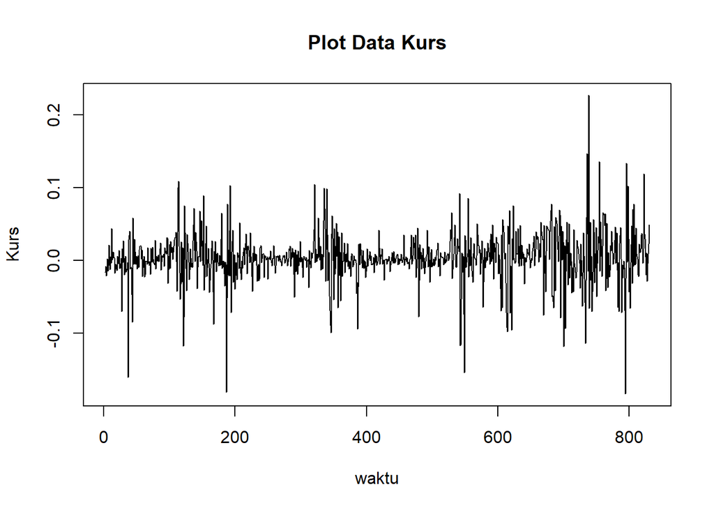

```r
plot.ts(btcprice.logdiff1, lty=1, xlab="waktu", ylab="Kurs", main="Plot Data Kurs")
```

Berdasarkan plot data deret waktu, terlihat bahwa data cenderung memiliki trend yang sudah stabi dan tidak ada pola trend atau musiman. Artinya data sudah stasioner.

### Identifikasi Model

#### Plot ACF

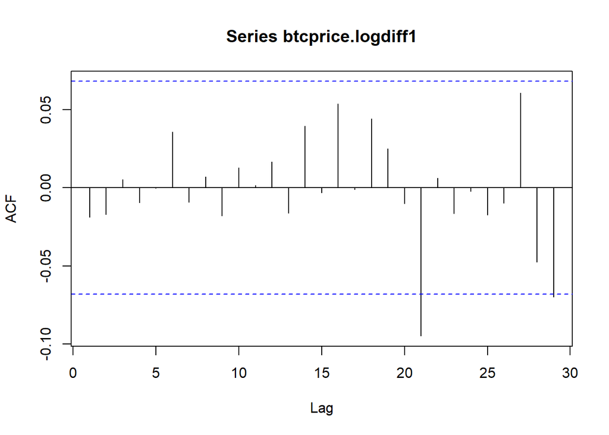

```r
acf(btcprice.logdiff1)
```

#### Plot PACF

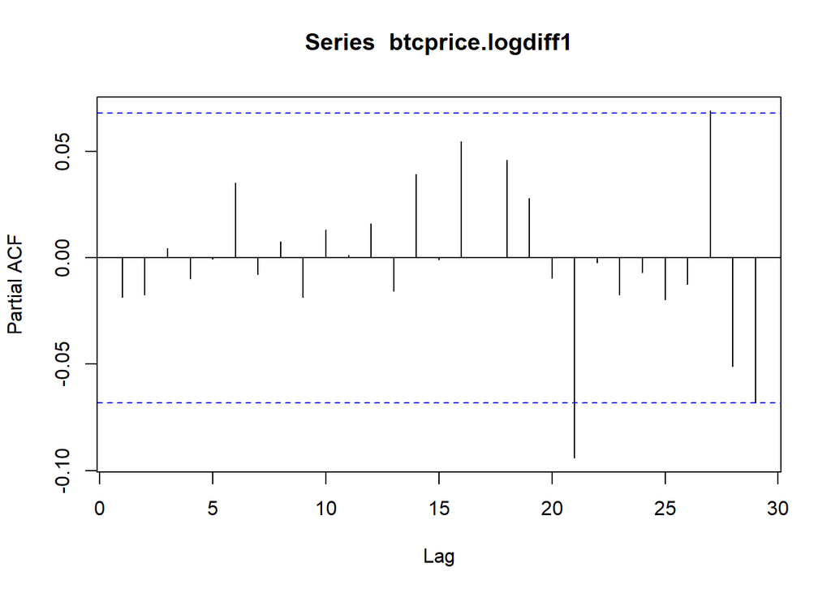

```r
pacf(btcprice.logdiff1)
```

Jika baik plot ACF maupun plot PACF keduanya dianggap tails off, maka model yang terbentuk adalah ARIMA(1,1,1)

#### Plot EACF

```r
eacf(btcprice.logdiff1)
```

```
## AR/MA
##   0 1 2 3 4 5 6 7 8 9 10 11 12 13
## 0 o o o o o o o o o o o  o  o  o
## 1 x o o o o o o o o o o  o  o  o
## 2 x x o o o o o o o o o  o  o  o
## 3 x x o o o o o o o o o  o  o  o
## 4 o x o x o o o o o o o  o  o  o
## 5 o x x x x o o o o o o  o  o  o
## 6 x x x o x x o o o o o  o  o  o
## 7 x o x o x x o o o o o  o  o  o
```

Identifikasi model menggunakan plot EACF dilakukan dengan melihat ujung segitiga pada pola segitiga nol. Dalam hal ini model tentatif yang terbentuk adalah ARIMA(0,1,0), ARIMA(1,1,1), dan ARIMA(2,1,2).